# SIM_Tugas_A_M0725093

Bagus Permana

2026-04-14

# A. Pendahuluan

Industri coffee chain sangat bergantung pada strategi marketing untuk meningkatkan penjualan dan profit. Namun, belum tentu peningkatan biaya marketing selalu menghasilkan profit yang optimal.

## Tujuan analisis:

- Mengetahui pengaruh marketing terhadap profit
- Menganalisis hubungan marketing, sales, dan profit

## 1. Load Library

```r
library(DBI)
library(ggplot2)
library(readxl)
library(dplyr)
library(odbc)
```

## 2. Impor data dari excel

```r
Coffe_Chain <- read_excel("Tugas SIM 2025B.xlsx")
View(Coffe_Chain)
```

## 3. Pemilihan Data

```r
df <- Coffe_Chain%>%
  select(Marketing, Sales, Profit) %>%
  na.omit()
df
```

```
## # A tibble: 4,248 × 3
##    Marketing Sales Profit
##        <dbl> <dbl>  <dbl>
##  1        24   219     94
##  2        27   190     68
##  3        26   234    101
##  4        14   100     30
##  5        15   134     54
##  6        23   180     53
##  7        47   341     99
##  8        57   150      0
##  9        19   140     33
## 10        22   130     17
## # ℹ 4,238 more rows
```

Insight yang dapat di ambil dari data yang dipilih yaitu Terdapat 3 variabel utama yaitu Marketing, Sales, dan Profit. Dari ketiga variabel tersebut, Marketing merupakan variabel independen yang akan dianalisis pengaruhnya terhadap Profit sebagai variabel dependen, serta Sales sebagai variabel kontrol.Dari data tersebut kita dapat mengambil insight seperti dapat melihat Statistika deskriptif dari variabel marketing, sales, dan profit yang ada pada data tersebut.Kita juga dapat melihat pengelompokan kategori marketing seperti Low, Medium, High. Kita dapat meihat rata-rata profit dari siap kategory amrketing. Kita dapat mengetahui hubungan dari profit dengan marketing dengan melihat sebaran data marketing dan profit. Kita juga dapat melihat rata-rata profit dari setiap kategori marketing dengan menggunakan visualisasi.

# B. Analisis Data

## 1. Statistika Deskriptif

```r
summary(df)
```

```
##    Marketing          Sales         Profit
##  Min.   :  0.00   Min.   : 17   Min.   :-638.0
##  1st Qu.: 13.00   1st Qu.:100   1st Qu.:  17.0
##  Median : 22.00   Median :138   Median :  40.0
##  Mean   : 31.19   Mean   :193   Mean   :  61.1
##  3rd Qu.: 39.00   3rd Qu.:230   3rd Qu.:  92.0
##  Max.   :156.00   Max.   :912   Max.   : 778.0
```

## 2. Dataframe baru untuk kategori Marketing

```r
df$Marketing_Category <- cut(df$Marketing,
                            breaks = quantile(df$Marketing, probs = c(0, 0.33, 0.66, 1), na.rm = TRUE),
                            labels = c("Low", "Medium", "High"),
                            include.lowest = TRUE)
```

## 3. Ringkasan statistik untuk setiap kategori Marketing

```r
summary_df <- df %>%
  group_by(Marketing_Category) %>%
  summarise(
    avg_profit = mean(Profit, na.rm = TRUE),
    avg_sales = mean(Sales, na.rm = TRUE),
    n = n()
  )
summary_df
```

```
## # A tibble: 3 × 4
##   Marketing_Category avg_profit avg_sales     n
##   <fct>                   <dbl>     <dbl> <int>
## 1 Low                      26.3      85.1  1462
## 2 Medium                   67.7     177.   1368
## 3 High                     90.6     319.   1418
```

## 4. Visualisasi Data

### a. Rata-rata Profit per Kategori Marketing

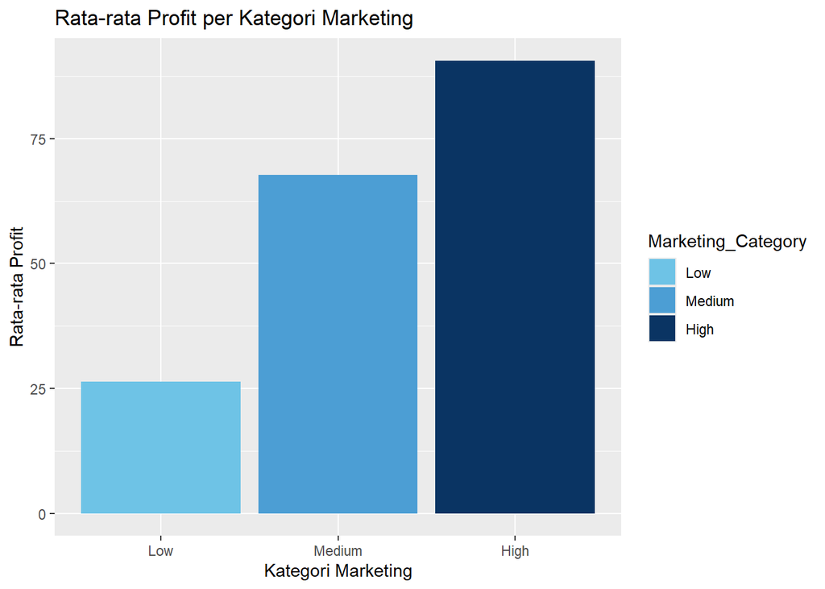

```r
ggplot(summary_df, aes(x = Marketing_Category, y = avg_profit,
                       fill = Marketing_Category)) +
  geom_col() +
  scale_fill_manual(values = c(
    "Low" = "#6EC3E6",
    "Medium" = "#4C9ED4",
    "High" = "#0A3463"
  )) +
  labs(title = "Rata-rata Profit per Kategori Marketing",
       x = "Kategori Marketing",
       y = "Rata-rata Profit")
```

### b. Sebaran Marketing vs Profit

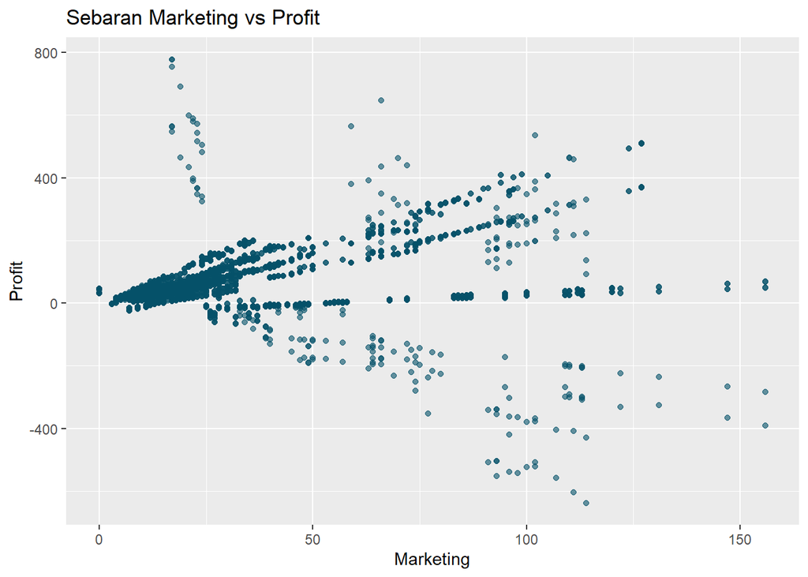

```r
ggplot(df, aes(x = Marketing, y = Profit)) +
  geom_point(alpha = 0.6, color = "#055169") +
  labs(title = "Sebaran Marketing vs Profit")
```

### Interpretasi hasil visualisasi

Dari visualisasi tersebut, terlihat bahwa terdapat sebaran data yang menunjukkan bahwa profit cenderung meningkat dengan peningkatan biaya marketing, namun tidak selalu linear. Hal ini mengindikasikan adanya kemungkinan diminishing return pada biaya marketing.